# EDAV Problem Set 4 Fall 2025

Author

Matthew Pisinski mp4523 and Mayur Suhas Kulkarni (msk2277)

### IMPORTANT NOTES FOR ALL QUESTIONS

See “Assignment Guidelines” under Pages in CourseWorks for instructions that apply to all assignments. (The guidelines will grow as the semester progresses so check back for each new assignment.)

**Do not use AI to answer interpretation questions. Keep your answers short and to the point. Overly verbose answers will be penalized.**

## 1. Regression diagnostics

Dataset: `alr4::Highway`

Fit the model with the mean function shown below and analyze the residuals to determine whether the assumptions of linear regression are met using the techniques discussed in class. (Use regular residuals, not standardized or studentized.) Your answer should be thorough: if multiple methods were presented (for example, for normality), use them all and compare the results.

$\hat{E}(rate|trks, acpt, slim) = \beta_0 + \beta_1trks + \beta_2acpt + \beta_3slim$

Describe what you see; your responses do not have to be “yes” or “no” answers to whether assumptions are met or not.

```r
library(ggplot2)
library(broom)
library(dplyr)
library(tidyr)
suppressWarnings({
library(parameters)
})
# Load required packages
library(alr4)

# load the dataset
data <- alr4::Highway
# inspect the dataset
head(data)
```

```
  adt trks lane acpt sigs  itg slim   len lwid shld htype rate
1  69    8    8  4.6 0.00 1.20   55  4.99   12   10   fai 4.58
2  73    8    4  4.4 0.00 1.43   60 16.11   12   10   fai 2.86
3  49   10    4  4.7 0.00 1.54   60  9.75   12   10   fai 3.02
4  61   13    6  3.8 0.00 0.94   65 10.65   12   10   fai 2.29
5  28   12    4  2.2 0.00 0.65   70 20.01   12   10   fai 1.61
6  30    6    4 24.8 1.84 0.34   55  5.97   12   10    pa 6.87
```

```r
# Fiting the linear regression model
model <- lm(rate ~ trks + acpt + slim, data = data)
summary(model)
```

```
Call:
lm(formula = rate ~ trks + acpt + slim, data = data)

Residuals:
    Min      1Q  Median      3Q     Max
-2.3652 -0.9490  0.1412  0.7481  2.4973

Coefficients:
            Estimate Std. Error t value Pr(>|t|)
(Intercept) 10.20690    2.79157   3.656 0.000833 ***
trks        -0.21994    0.08705  -2.527 0.016195 *
acpt         0.09815    0.02871   3.419 0.001613 **
slim        -0.09844    0.04467  -2.204 0.034222 *
---
Signif. codes:  0 '***' 0.001 '**' 0.01 '*' 0.05 '.' 0.1 ' ' 1

Residual standard error: 1.175 on 35 degrees of freedom
Multiple R-squared:  0.6774,    Adjusted R-squared:  0.6497
F-statistic:  24.5 on 3 and 35 DF,  p-value: 1.014e-08
```

```r
# Extract regular residuals
residuals <- residuals(model)
fitted_values <- fitted(model)
```

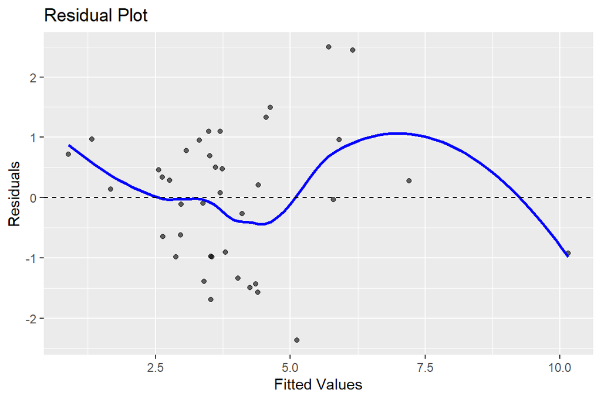

```r
#analyzing how good the linearity assumption holds

aug <- broom::augment(model, data=data)

# We are checking Linearity, Constant Variance for residuals, Residuals are independent
#Plot residual against fitted values
ggplot(aug, aes(x=.fitted, y=.resid)) +
  geom_point(alpha=0.6) +
  geom_smooth(method = "loess", se = FALSE, color = "blue") +
  geom_hline(yintercept=0, linetype='dashed') +
  labs(x="Fitted Values", y='Residuals', title='Residual Plot')
```

The curved LOWESS and structured swings in residuals across fitted values indicate nonlinearity, so a simple linear model is misspecified here.

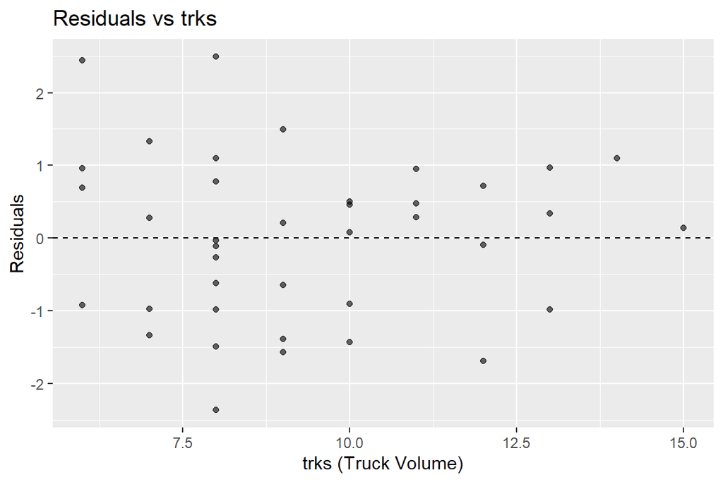

```r
aug <- augment(model)

# Residuals vs trks
ggplot(aug, aes(x = trks, y = .resid)) +
  geom_point(alpha = 0.6) +
  geom_hline(yintercept = 0, linetype = "dashed") +
  labs(title = "Residuals vs trks",
       x = "trks (Truck Volume)",
       y = "Residuals")
```

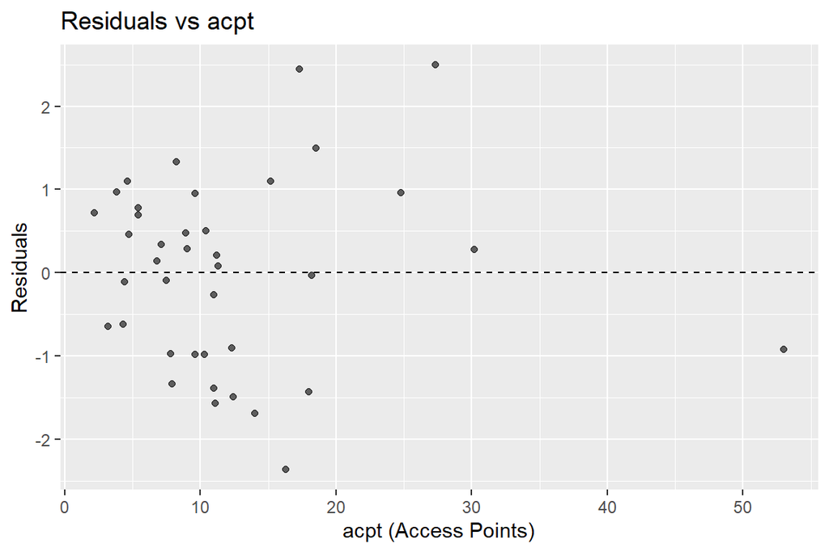

```r
# Residuals vs acpt
ggplot(aug, aes(x = acpt, y = .resid)) +
  geom_point(alpha = 0.6) +
  geom_hline(yintercept = 0, linetype = "dashed") +
  labs(title = "Residuals vs acpt",
       x = "acpt (Access Points)",
       y = "Residuals")
```

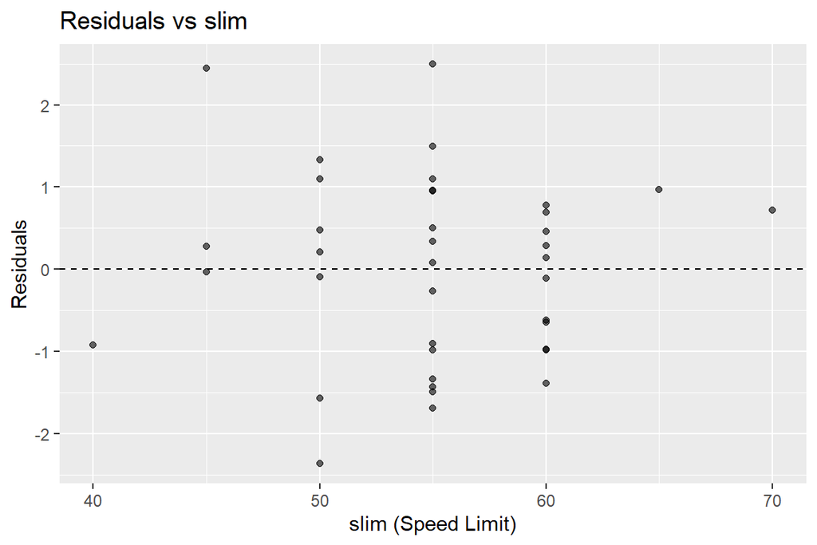

```r
# Residuals vs slim
ggplot(aug, aes(x = slim, y = .resid)) +
  geom_point(alpha = 0.6) +
  geom_hline(yintercept = 0, linetype = "dashed") +
  labs(title = "Residuals vs slim",
       x = "slim (Speed Limit)",
       y = "Residuals")
```

1. Residuals vs acpt (Access Points) Wider spread at low acpt and one high-acpt point suggest mild heteroscedasticity. This suggests non-linearity.
2. Residuals vs slim (Speed Limit)

Residuals are centered around zero at each posted speed with no systematic trend, so linearity with respect to speed limit looks acceptable. Slightly larger spread near 55–60 suggests mild heteroscedasticity. Does not look to be a strong violation without a clear fanning pattern.

3. Residuals vs trks (Truck Volume)

Residuals scatter randomly around zero across trks with no curvature and roughly constant spread, so the linearity assumption for trks looks fine.

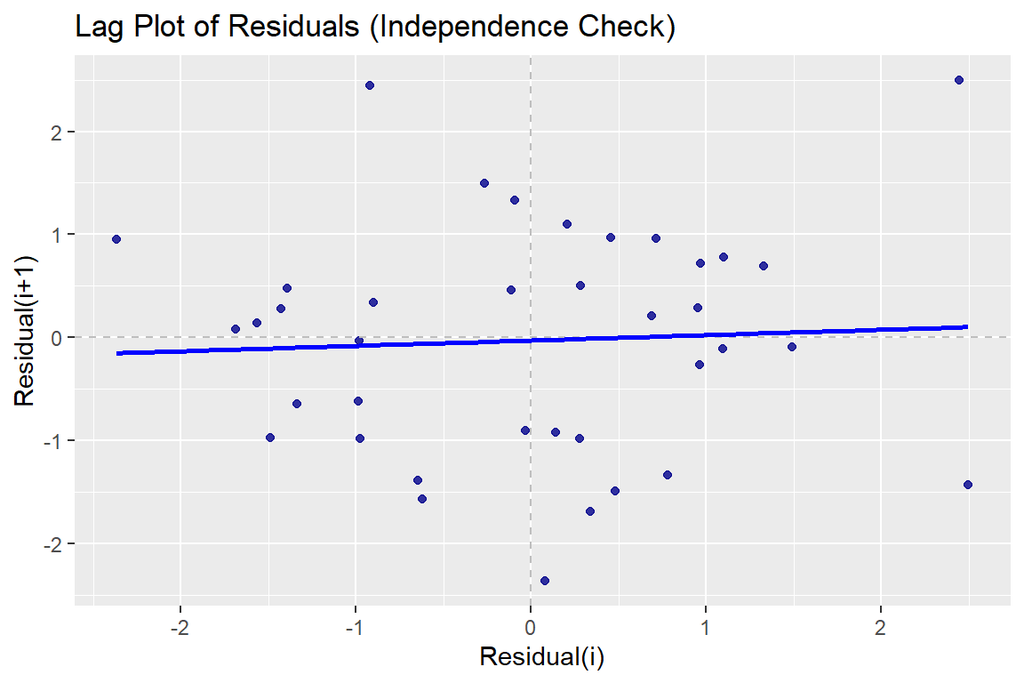

```r
lag_df <- data.frame(
  resid_i = aug$.resid[-length(aug$.resid)],
  resid_i1 = aug$.resid[-1]
)


ggplot(lag_df, aes(x = resid_i, y = resid_i1)) +
  geom_point(color = "darkblue", alpha = 0.8) +
  geom_hline(yintercept = 0, linetype = "dashed", color = "gray") +
  geom_vline(xintercept = 0, linetype = "dashed", color = "gray") +
  geom_smooth(method = "lm", se = FALSE, color = "blue", size = 1) +
  labs(
    x = "Residual(i)",
    y = "Residual(i+1)",
    title = "Lag Plot of Residuals (Independence Check)"
  )
```

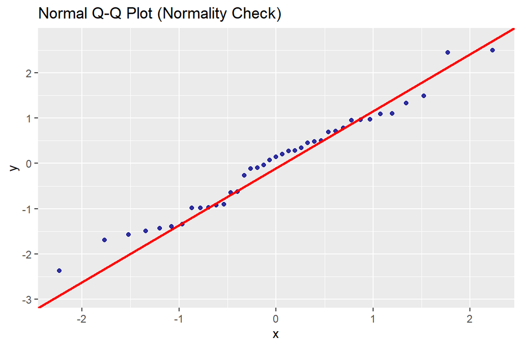

```r
# Q-Q Plot of Residuals
ggplot(aug, aes(sample = .resid)) +
  stat_qq(color = "darkblue", alpha = 0.8) +
  stat_qq_line(color = "red", size = 1) +
  labs(title = "Normal Q-Q Plot (Normality Check)")
```

Points lie close to the reference line with only small tail deviations, so residuals look approximately normal. There are no obvious skew or extreme outliers and the normality assumption for linear regression appears acceptable.

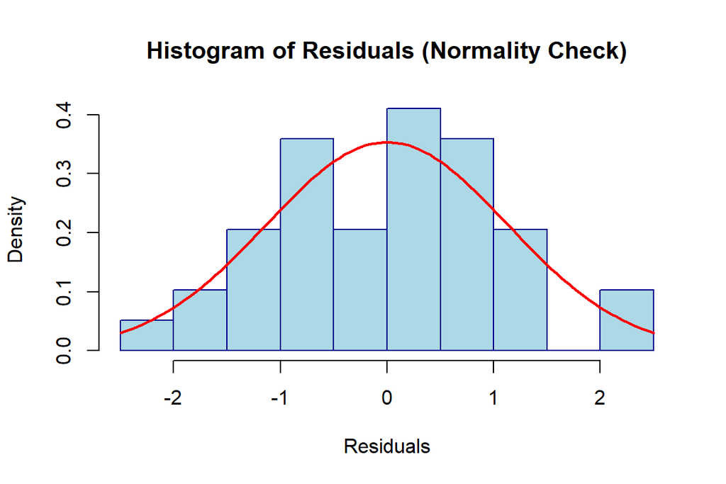

```r
#Histogram with Normal Overlay

hist(residuals, breaks = 15,
     main = "Histogram of Residuals (Normality Check)",
     xlab = "Residuals",
     col = "lightblue",
     border = "darkblue",
     probability = TRUE)
curve(dnorm(x, mean = mean(residuals), sd = sd(residuals)),
      col = "red", lwd = 2, add = TRUE)
```

The residuals appear to follow a normal distribution in the center around 0 and the tails are slightly lighter than expected and indicate fewer extreme values than a perfect normal. There is no obvious skewness or multimodality. This supports the normality assumption for residuals with very mild departures at the extremes.

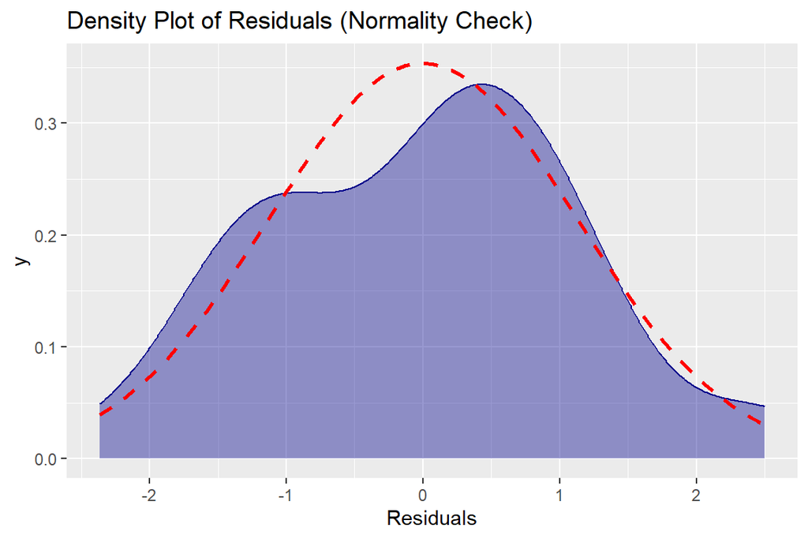

```r
# Density Plot of Residuals with legend
# Density Plot with filled area and legend
ggplot(aug, aes(x = .resid)) +
  geom_density(aes(fill = "Actual"), alpha = 0.4, color = "darkblue") +
  stat_function(aes(color = "Normal"),
                fun = dnorm,
                args = list(mean = mean(aug$.resid), sd = sd(aug$.resid)),
                size = 1, linetype = "dashed") +
  scale_fill_manual(values = c("Actual" = "darkblue")) +
  scale_color_manual(values = c("Normal" = "red")) +
  labs(title = "Density Plot of Residuals (Normality Check)",
       x = "Residuals",
       fill = "", color = "") +
  theme(legend.position = "topright")
```

The residual density closely tracks the normal curve with only small shape differences.So normality looks reasonable. Slight asymmetry around the peak hints at mild tail departure but nothing severe.

```r
shapiro_test <- shapiro.test(residuals)
print(shapiro_test)
```

```
    Shapiro-Wilk normality test

data:  residuals
W = 0.97714, p-value = 0.6002
```

The Shapiro-Wilk test for normality gives a test statistic of W=0.977 and a p-value of 0.60. Because the p-value is far above 0.05, we fail to reject the null hypothesis and conclude that the residuals show no significant departure from normality.

## 2. Coefficient plots

1. Using the model from question 1., $\hat{E}(rate|trks, acpt, slim) = \beta_0 + \beta_1trks + \beta_2acpt + \beta_3slim$, create a coefficient plot showing 95% confidence intervals for the model coefficients.

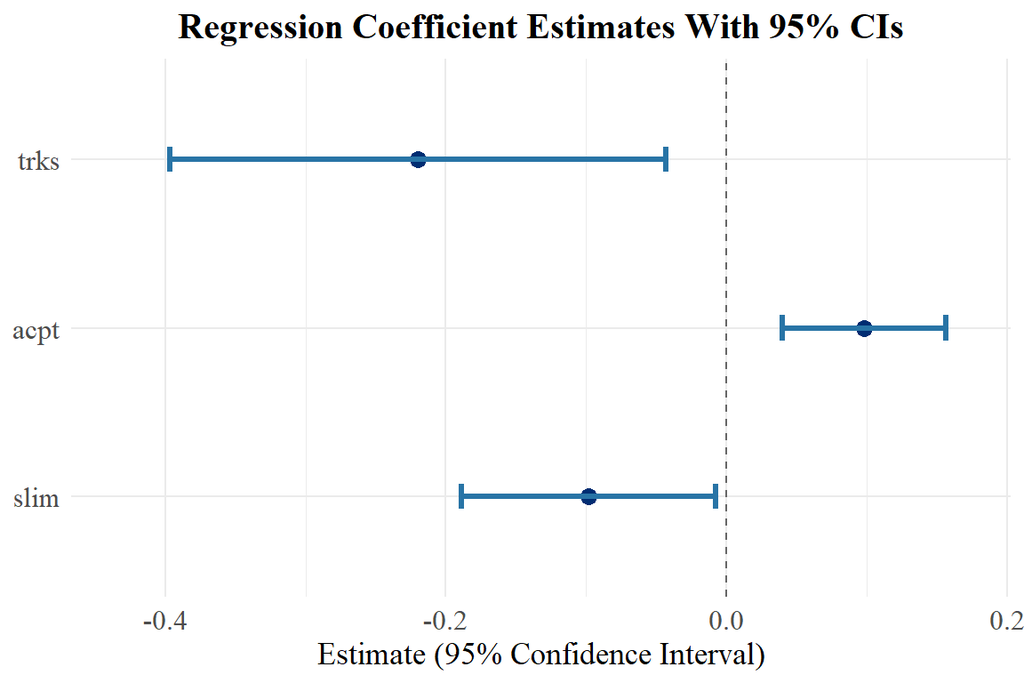

```r
#fitting the model
fit <- lm(rate ~ trks + acpt + slim, data = Highway)
#95 percent confidence intervals and co efficient estimates
library(broom)
library(ggplot2)
coef_estimates <- coef(fit)
conf_int <- confint(fit)
coef_df <- broom::tidy(fit, conf.int = TRUE)

# Remove the intercept row
coef_df <- coef_df[coef_df$term != "(Intercept)", ]

# Reorder terms
coef_df$term <- factor(coef_df$term, levels = rev(coef_df$term))

ggplot(coef_df, aes(x = estimate, y = term)) +
  geom_point(size = 3, color = "#002D72") +  # Columbia blue for academic look
  geom_errorbarh(aes(xmin = conf.low, xmax = conf.high), height = 0.15, color = "#2874A6", size = 1.1) +
  geom_vline(xintercept = 0, linetype = "dashed", color = "grey40") +
  labs(
    title = "Regression Coefficient Estimates With 95% CIs",
    x = "Estimate (95% Confidence Interval)",
    y = NULL
  ) +
  theme_minimal(base_family = "serif") +
  theme(
    plot.title = element_text(face = "bold", size = 15, hjust = 0.5),
    axis.text = element_text(size = 12),
    axis.title.x = element_text(size = 13)
  ) +
  coord_cartesian(xlim = c(min(coef_df$conf.low) * 1.1, max(coef_df$conf.high) * 1.1))
```

2. Interpret the graph in a.

3. Recreate the graph in a. with standardized coefficients.

```r
# Standardize predictor and outcome variables
dat_std <- Highway
dat_std$rate_z <- scale(dat_std$rate)
dat_std$trks_z <- scale(dat_std$trks)
dat_std$acpt_z <- scale(dat_std$acpt)
dat_std$slim_z <- scale(dat_std$slim)

fit_std <- lm(rate_z ~ trks_z + acpt_z + slim_z, data = dat_std)

library(broom)
coef_std <- tidy(fit_std, conf.int = TRUE)
coef_std$term <- factor(coef_std$term, levels = rev(coef_std$term))
```

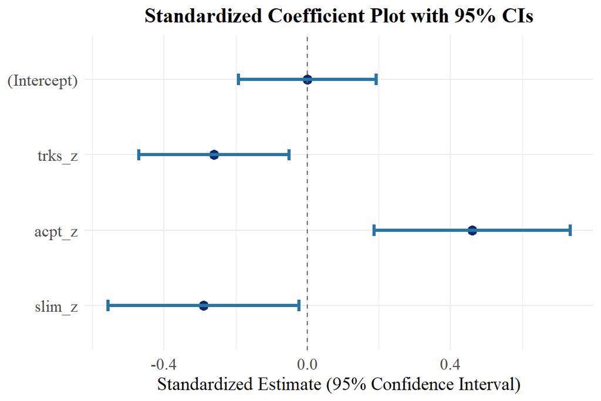

```r
library(ggplot2)
ggplot(coef_std, aes(x = estimate, y = term)) +
  geom_point(size = 3, color = "#002D72") +
  geom_errorbarh(aes(xmin = conf.low, xmax = conf.high), height = 0.15, color = "#2874A6", size = 1.1) +
  geom_vline(xintercept = 0, linetype = "dashed", color = "grey40") +
  labs(
    title = "Standardized Coefficient Plot with 95% CIs",
    x = "Standardized Estimate (95% Confidence Interval)",
    y = NULL
  ) +
  theme_minimal(base_family = "serif") +
  theme(
    plot.title = element_text(face = "bold", size = 15, hjust = 0.5),
    axis.text = element_text(size = 12),
    axis.title.x = element_text(size = 13)
  )
```

4. Interpret the graph in c., comparing to a.

5. Create a coefficient x effect plot.

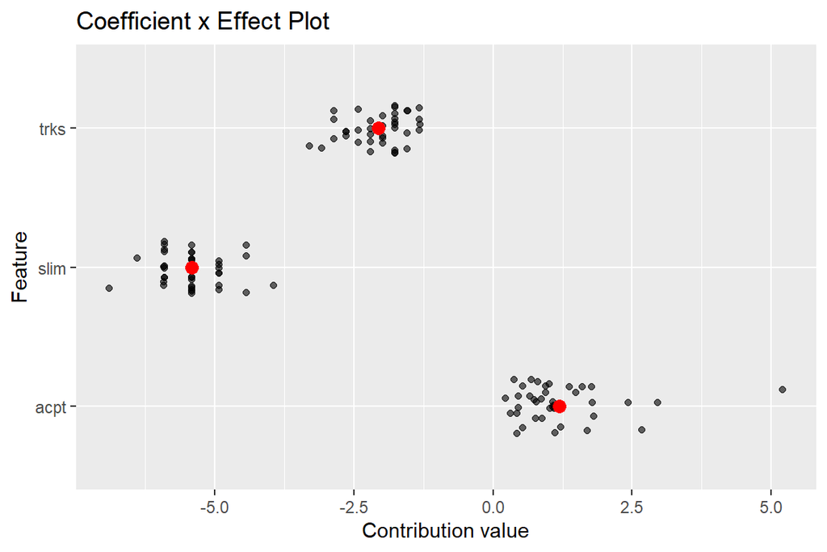

```r
# add feature contribution
aug$contrib_trks <- aug$trks * coef(fit)['trks']
aug$contrib_slim <- aug$slim * coef(fit)['slim']
aug$contrib_acpt <- aug$acpt * coef(fit)['acpt']

# create long formatted table for plotting
contrib_long <- aug |>
  select(contrib_trks, contrib_slim, contrib_acpt) |>
  mutate(obs = row_number()) |>
  pivot_longer(-obs, names_to = "feature", values_to = "value") |>
  mutate(feature = sub("^contrib_", "", feature))

# calculate mean contribution value for each feature
stat_means <- contrib_long |>
  group_by(feature) |>
  summarise(mean_contrib = mean(value))

# Create coefficient x effect plot
ggplot(contrib_long, aes(x = value, y = feature)) +
  geom_jitter(alpha = 0.6, height = 0.2) +
  geom_point(data = stat_means,
             aes(x = mean_contrib, y = feature),
             color = "red",
             size = 3) +
  labs(title = "Coefficient x Effect Plot",
       x = "Contribution value",
       y = "Feature")
```

6. Do you learn anything new from part e.?

The effect plots reinforce what you saw in the coefficient plot. trks and slim have negative associations with rate and acpt has a positive effect. The added value from this plot is a direct, easily interpretable view of the practical impact of each input, and the uncertainty around those predictions.We see an extreme outlier near +5.0 for acpt requiring further investigation.

## 3. Variable added plots

1. Find the coefficients for the following models with mean functions:

model 1: $\hat{E}(rate|trks, acpt) = b_0 + b_1trks + b_2acpt$

model 2: $\hat{E}(rate|slim) = b_0 + b_1slim$

```r
model1 <- lm(rate ~ trks + acpt, data = Highway)
model2 <- lm(rate ~ slim, data = Highway)

coef(model1)  # Coefficients for model 1
```

```
(Intercept)        trks        acpt
  4.4293236  -0.2341766   0.1389639
```

```r
coef(model2)  # Coefficients for model 2
```

```
(Intercept)        slim
 16.6510256  -0.2312308
```

```r
summary(model1)$coefficients
```

```
              Estimate Std. Error   t value     Pr(>|t|)
(Intercept)  4.4293236 1.00856483  4.391709 9.470679e-05
trks        -0.2341766 0.09134413 -2.563675 1.467827e-02
acpt         0.1389639 0.02308066  6.020793 6.519066e-07
```

```r
summary(model2)$coefficients
```

```
              Estimate Std. Error  t value     Pr(>|t|)
(Intercept) 16.6510256 2.26067813  7.36550 9.287266e-09
slim        -0.2312308 0.04087863 -5.65652 1.832965e-06
```

Compare $R^2$ from the full model in question 1 to the $R^2$ values for the two models. What do you learn about the regressors from these values?

```r
summary(fit)$r.squared      # Full model
```

```
[1] 0.6773765
```

```r
summary(model1)$r.squared   # Model 1
```

```
[1] 0.6326149
```

```r
summary(model2)$r.squared   # Model 2
```

```
[1] 0.4637387
```

$R^2$ represents the proportion of variance in rate explained by the predictors.

The full model explains approximately 67.7% of the variance in rate, while Model 1 explains 63.3% and Model 2 explains 46.4%.

Model 2 uses only slim and has the lowest $R^2$ (0.464). This suggests that while slim is useful, it cannot explain as the variance alone as the combination of predictors in the other models can.

2. How much additional variation is explained by the addition of `slim` to model 1?

Adding slim to the model explains an additional 4.48% of the variance in rate which is beyond what is explained by trks and acpt alone. The fact that $R^2$ increases by about 4.5% indicates that slim provides meaningful new information for predicting rate that cannot be captured by the other predictors.

3. Create an added variable plot for `slim` and add the best fitting line. (Hint: unlike the example in class, there are *two* other regressors in the problem besides `slim`.)

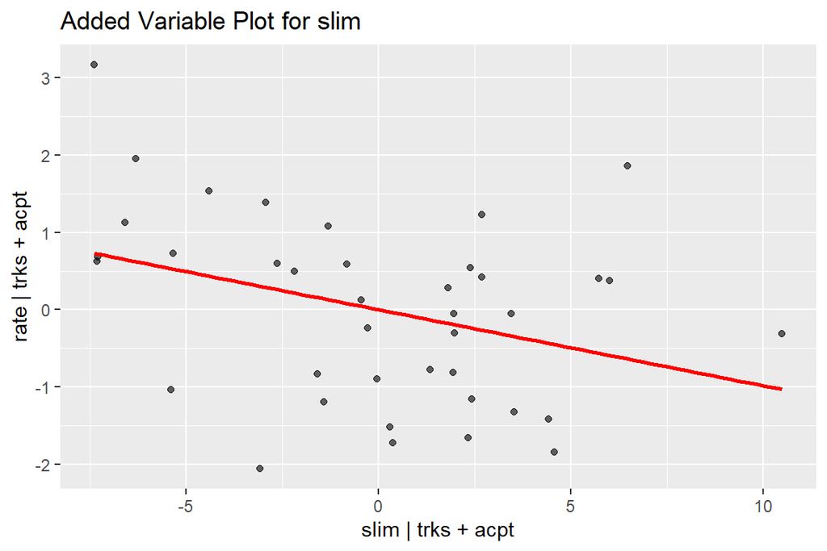

```r
# Step 1: Get residuals from rate ~ trks + acpt
resid_y <- resid(lm(rate ~ trks + acpt, data = Highway))

# Step 2: Get residuals from slim ~ trks + acpt
resid_x <- resid(lm(slim ~ trks + acpt, data = Highway))

# Create data frame
residual_df <- data.frame(
  resid_x = resid_x,
  resid_y = resid_y
)

# Added variable plot
ggplot(residual_df, aes(x = resid_x, y = resid_y)) +
  geom_point(alpha = 0.6) +
  geom_smooth(method = "lm", se = FALSE, color = "red") +
  labs(
    x = "slim | trks + acpt",
    y = "rate | trks + acpt",
    title = "Added Variable Plot for slim"
  )
```

4. Determine and interpret the slope of the line in part c.

```r
model_resid = lm(resid_y ~ resid_x, data = residual_df)
summary(model_resid)
```

```
Call:
lm(formula = resid_y ~ resid_x, data = residual_df)

Residuals:
    Min      1Q  Median      3Q     Max
-2.3652 -0.9490  0.1412  0.7481  2.4973

Coefficients:
              Estimate Std. Error t value Pr(>|t|)
(Intercept) -1.492e-16  1.831e-01   0.000   1.0000
resid_x     -9.844e-02  4.345e-02  -2.266   0.0294 *
---
Signif. codes:  0 '***' 0.001 '**' 0.01 '*' 0.05 '.' 0.1 ' ' 1

Residual standard error: 1.143 on 37 degrees of freedom
Multiple R-squared:  0.1218,    Adjusted R-squared:  0.0981
F-statistic: 5.133 on 1 and 37 DF,  p-value: 0.02941
```

The slope of the line in the added variable plot is -0.0984.

The slope is around -0.098, indicating that for each 1 unit increase in slim is associated with around -0.1 decrease in rate. The effect is small but statistically significant at 5% significance level.

5. Determine and the $R^2$ of the regression in part d. and relate it to the $R^2$ values from part a.

```r
summary(model_resid)$r.squared
```

```
[1] 0.1218385
```

With R^2 close to 0.12 in the added‑variable model, slim explains roughly 12% of the residual variation in rate once trks and acpt are removed, indicating a small effect.